# Predict Bike Sharing Demand with AutoGluon Template

## Project: Predict Bike Sharing Demand with AutoGluon

This notebook is a template with each step that you need to complete for the project.

Please fill in your code where there are explicit `?` markers in the notebook. You are welcome to add more cells and code as you see fit.

Once you have completed all the code implementations, please export your notebook as a HTML file so the reviews can view your code. Make sure you have all outputs correctly outputted.

`File-> Export Notebook As... -> Export Notebook as HTML`

There is a writeup to complete as well after all code implememtation is done. Please answer all questions and attach the necessary tables and charts. You can complete the writeup in either markdown or PDF.

Completing the code template and writeup template will cover all of the rubric points for this project.

The rubric contains "Stand Out Suggestions" for enhancing the project beyond the minimum requirements. The stand out suggestions are optional. If you decide to pursue the "stand out suggestions", you can include the code in this notebook and also discuss the results in the writeup file.

## Step 1: Create an account with Kaggle

### Create Kaggle Account and download API key

Below is example of steps to get the API username and key. Each student will have their own username and key.

1. Open account settings.

2. Scroll down to API and click Create New API Token.

3. Open up `kaggle.json` and use the username and key.


## Step 2: Download the Kaggle dataset using the kaggle python library

### Open up Sagemaker Studio and use starter template

1. Notebook should be using a `ml.t3.medium` instance (2 vCPU + 4 GiB)
2. Notebook should be using kernal: `Python 3 (MXNet 1.8 Python 3.7 CPU Optimized)`

### Install packages

```python
!pip install -U pip
!pip install -U setuptools wheel
!pip install -U "mxnet<2.0.0" bokeh==2.0.1
!pip install autogluon --no-cache-dir
# Without --no-cache-dir, smaller aws instances may have trouble installing
```

[output not shown]

### Setup Kaggle API Key

```python
# create the .kaggle directory and an empty kaggle.json file
!mkdir -p  ~/.kaggle
!touch  ~/.kaggle/kaggle.json
!chmod 600  ~/.kaggle/kaggle.json
```

```python
# create the .kaggle directory and an empty kaggle.json file
!mkdir -p  /home/.kaggle
!touch  /home/.kaggle/kaggle.json
!chmod 600  /home/.kaggle/kaggle.json
```

```python
ls ~/.kaggle
```

```
kaggle.json
```

```python
ls /home
```

```
sagemaker-user/
```

```python
# Fill in your user name and key from creating the kaggle account and API token file
import json
kaggle_username ="" #"FILL_IN_USERNAME"

kaggle_key ="" #"FILL_IN_KEY"


# Save API token the kaggle.json file
with open("/home/.kaggle/kaggle.json", "w") as f:
    f.write(json.dumps({"username": kaggle_username, "key": kaggle_key}))
```

### Download and explore dataset

### Go to the bike sharing demand competition and agree to the terms

```python
%pip install kaggle
```

```python
!echo f'{"username":"{kaggle_username}","key":"{kaggle_key}"}' > ~/.kaggle/kaggle.json
```

### Set credentials as Environment Variables

```python
import os

os.environ['KAGGLE_USERNAME'] = kaggle_username
os.environ['KAGGLE_KEY'] = kaggle_key
```

```python
ls ..  -la
```

```
total 12
drwxr-xr-x  6 sagemaker-user users     97 May  4 02:34 ./
drwx------  9 sagemaker-user nogroup  184 May  4 02:42 ../
drwxr-xr-x 12 sagemaker-user users    202 May  4 02:45 .conda/
drwxr-xr-x  8 sagemaker-user users    185 May  5 03:22 .git/
drwxr-xr-x  3 sagemaker-user users     23 May  3 02:20 .github/
-rw-r--r--  1 sagemaker-user users     43 May  3 02:20 CODEOWNERS
-rw-r--r--  1 sagemaker-user users     60 May  3 02:20 README.md
drwxr-xr-x  4 sagemaker-user users   4096 May  7 03:16 project/
```

```python
# Download the dataset, it will be in a .zip file so you'll need to unzip it as well.
!kaggle competitions download -c bike-sharing-demand
# If you already downloaded it you can use the -o command to overwrite the file
#!unzip -o bike-sharing-demand.zip
```

```
bike-sharing-demand.zip: Skipping, found more recently modified local copy (use --force to force download)
```

```python
# If you already downloaded it you can use the -o command to overwrite the file
!unzip -o bike-sharing-demand.zip
```

```
Archive:  bike-sharing-demand.zip
  inflating: sampleSubmission.csv
  inflating: test.csv
  inflating: train.csv
```

```python
import pandas as pd
from autogluon.tabular import TabularPredictor
```

```python
# Create the train dataset in pandas by reading the csv
# Set the parsing of the datetime column so you can use some of the `dt` features in pandas later
train = pd.read_csv("train.csv", index_col=0, header=0)
train.head()
```

| datetime | season | holiday | workingday | weather | temp | atemp | humidity | windspeed | casual | registered | count |
| --- | --- | --- | --- | --- | --- | --- | --- | --- | --- | --- | --- |
| 2011-01-01 00:00:00 | 1 | 0 | 0 | 1 | 9.84 | 14.395 | 81 | 0.0 | 3 | 13 | 16 |
| 2011-01-01 01:00:00 | 1 | 0 | 0 | 1 | 9.02 | 13.635 | 80 | 0.0 | 8 | 32 | 40 |
| 2011-01-01 02:00:00 | 1 | 0 | 0 | 1 | 9.02 | 13.635 | 80 | 0.0 | 5 | 27 | 32 |
| 2011-01-01 03:00:00 | 1 | 0 | 0 | 1 | 9.84 | 14.395 | 75 | 0.0 | 3 | 10 | 13 |
| 2011-01-01 04:00:00 | 1 | 0 | 0 | 1 | 9.84 | 14.395 | 75 | 0.0 | 0 | 1 | 1 |

### Check the types of columns

```python
train.dtypes
```

```
season          int64
holiday         int64
workingday      int64
weather         int64
temp          float64
atemp         float64
humidity        int64
windspeed     float64
casual          int64
registered      int64
count           int64
dtype: object
```

```python
# check the type of index
#dtype is object
train.index
```

```
Index(['2011-01-01 00:00:00', '2011-01-01 01:00:00', '2011-01-01 02:00:00',
       '2011-01-01 03:00:00', '2011-01-01 04:00:00', '2011-01-01 05:00:00',
       '2011-01-01 06:00:00', '2011-01-01 07:00:00', '2011-01-01 08:00:00',
       '2011-01-01 09:00:00',
       ...
       '2012-12-19 14:00:00', '2012-12-19 15:00:00', '2012-12-19 16:00:00',
       '2012-12-19 17:00:00', '2012-12-19 18:00:00', '2012-12-19 19:00:00',
       '2012-12-19 20:00:00', '2012-12-19 21:00:00', '2012-12-19 22:00:00',
       '2012-12-19 23:00:00'],
      dtype='object', name='datetime', length=10886)
```

```python
# cast index to datetime
train.index = pd.to_datetime(train.index)
train.index
```

```
DatetimeIndex(['2011-01-01 00:00:00', '2011-01-01 01:00:00',
               '2011-01-01 02:00:00', '2011-01-01 03:00:00',
               '2011-01-01 04:00:00', '2011-01-01 05:00:00',
               '2011-01-01 06:00:00', '2011-01-01 07:00:00',
               '2011-01-01 08:00:00', '2011-01-01 09:00:00',
               ...
               '2012-12-19 14:00:00', '2012-12-19 15:00:00',
               '2012-12-19 16:00:00', '2012-12-19 17:00:00',
               '2012-12-19 18:00:00', '2012-12-19 19:00:00',
               '2012-12-19 20:00:00', '2012-12-19 21:00:00',
               '2012-12-19 22:00:00', '2012-12-19 23:00:00'],
              dtype='datetime64[ns]', name='datetime', length=10886, freq=None)
```

```python
# Simple output of the train dataset to view some of the min/max/varition of the dataset features.
train.describe()
```

|  | season | holiday | workingday | weather | temp | atemp | humidity | windspeed | casual | registered | count |
| --- | --- | --- | --- | --- | --- | --- | --- | --- | --- | --- | --- |
| count | 10886.000000 | 10886.000000 | 10886.000000 | 10886.000000 | 10886.00000 | 10886.000000 | 10886.000000 | 10886.000000 | 10886.000000 | 10886.000000 | 10886.000000 |
| mean | 2.506614 | 0.028569 | 0.680875 | 1.418427 | 20.23086 | 23.655084 | 61.886460 | 12.799395 | 36.021955 | 155.552177 | 191.574132 |
| std | 1.116174 | 0.166599 | 0.466159 | 0.633839 | 7.79159 | 8.474601 | 19.245033 | 8.164537 | 49.960477 | 151.039033 | 181.144454 |
| min | 1.000000 | 0.000000 | 0.000000 | 1.000000 | 0.82000 | 0.760000 | 0.000000 | 0.000000 | 0.000000 | 0.000000 | 1.000000 |
| 25% | 2.000000 | 0.000000 | 0.000000 | 1.000000 | 13.94000 | 16.665000 | 47.000000 | 7.001500 | 4.000000 | 36.000000 | 42.000000 |
| 50% | 3.000000 | 0.000000 | 1.000000 | 1.000000 | 20.50000 | 24.240000 | 62.000000 | 12.998000 | 17.000000 | 118.000000 | 145.000000 |
| 75% | 4.000000 | 0.000000 | 1.000000 | 2.000000 | 26.24000 | 31.060000 | 77.000000 | 16.997900 | 49.000000 | 222.000000 | 284.000000 |
| max | 4.000000 | 1.000000 | 1.000000 | 4.000000 | 41.00000 | 45.455000 | 100.000000 | 56.996900 | 367.000000 | 886.000000 | 977.000000 |

```python
train.isna().sum().sum()
```

```
0
```

```python
# Create the test pandas dataframe in pandas by reading the csv, remember to parse the datetime!
test = pd.read_csv('test.csv', index_col= 0 )
test.index = pd.to_datetime(test.index)

test.head()
```

| datetime | season | holiday | workingday | weather | temp | atemp | humidity | windspeed |
| --- | --- | --- | --- | --- | --- | --- | --- | --- |
| 2011-01-20 00:00:00 | 1 | 0 | 1 | 1 | 10.66 | 11.365 | 56 | 26.0027 |
| 2011-01-20 01:00:00 | 1 | 0 | 1 | 1 | 10.66 | 13.635 | 56 | 0.0000 |
| 2011-01-20 02:00:00 | 1 | 0 | 1 | 1 | 10.66 | 13.635 | 56 | 0.0000 |
| 2011-01-20 03:00:00 | 1 | 0 | 1 | 1 | 10.66 | 12.880 | 56 | 11.0014 |
| 2011-01-20 04:00:00 | 1 | 0 | 1 | 1 | 10.66 | 12.880 | 56 | 11.0014 |

```python
# Same thing as train and test dataset
# index_col = 0 set first colum (datetime) as index of the dataframe
submission = pd.read_csv("sampleSubmission.csv",
    index_col= 0
    )
# cast index to datetime
submission.index = pd.to_datetime(submission.index)

submission.head()
```

| datetime | count |
| --- | --- |
| 2011-01-20 00:00:00 | 0 |
| 2011-01-20 01:00:00 | 0 |
| 2011-01-20 02:00:00 | 0 |
| 2011-01-20 03:00:00 | 0 |
| 2011-01-20 04:00:00 | 0 |

```python
#!conda install -p /home/sagemaker-user/Predict-Bike-Sharing-Demand-with-Machine-Learning/.conda ipykernel --update-deps --force-reinstall
```

## Step 3: Train a model using AutoGluon’s Tabular Prediction

Requirements:

- We are prediting `count`, so it is the label we are setting.
- Ignore `casual` and `registered` columns as they are also not present in the test dataset.
- Use the `root_mean_squared_error` as the metric to use for evaluation.
- Set a time limit of 10 minutes (600 seconds).
- Use the preset `best_quality` to focus on creating the best model.

```python
# drop casual and registered  columns
train = train.drop(["casual","registered"],axis = 1 )
train.columns
```

```
Index(['season', 'holiday', 'workingday', 'weather', 'temp', 'atemp',
       'humidity', 'windspeed', 'count'],
      dtype='object')
```

```python
predictor = TabularPredictor(
    label = "count",
    problem_type = "regression",
    eval_metric = "root_mean_squared_error",
    verbosity = 4, # max information with log validation score every iteration

)
```

```
No path specified. Models will be saved in: "AutogluonModels/ag-20240507_040243"
```

```python
# check all columns have a numeric type or category
# int or float
train.dtypes
```

```
season          int64
holiday         int64
workingday      int64
weather         int64
temp          float64
atemp         float64
humidity        int64
windspeed     float64
count           int64
dtype: object
```

```python
predictor.fit(
    train_data = train,
    time_limit = 10*60, # 10 minutes
    presets = ["best_quality"]
)
```

[output not shown]

[output cut: 1182 more lines]

```
	Ensemble Weights: {'RandomForestMSE_BAG_L2': 0.32, 'CatBoost_BAG_L2': 0.32, 'NeuralNetFastAI_BAG_L1': 0.12, 'LightGBMXT_BAG_L2': 0.12, 'ExtraTreesMSE_BAG_L1': 0.08, 'XGBoost_BAG_L1': 0.04}
	-140.5078	 = Validation score   (-root_mean_squared_error)
	0.1s	 = Training   runtime
	0.0s	 = Validation runtime
Saving AutogluonModels/ag-20240507_040243/models/trainer.pkl
Saving AutogluonModels/ag-20240507_040243/models/trainer.pkl
Saving AutogluonModels/ag-20240507_040243/models/trainer.pkl
AutoGluon training complete, total runtime = 433.93s ... Best model: "WeightedEnsemble_L3"
Loading: AutogluonModels/ag-20240507_040243/models/trainer.pkl
Saving AutogluonModels/ag-20240507_040243/models/trainer.pkl
Saving AutogluonModels/ag-20240507_040243/learner.pkl
Saving AutogluonModels/ag-20240507_040243/predictor.pkl
Saving AutogluonModels/ag-20240507_040243/__version__ with contents "1.1.0"
Saving AutogluonModels/ag-20240507_040243/metadata.json
TabularPredictor saved. To load, use: predictor = TabularPredictor.load("AutogluonModels/ag-20240507_040243")
```

```
<autogluon.tabular.predictor.predictor.TabularPredictor at 0x7fb12e43c430>
```

### Review AutoGluon's training run with ranking of models that did the best.

```python
predictor.fit_summary()
```

```
Loading: AutogluonModels/ag-20240507_040243/models/KNeighborsUnif_BAG_L1/model.pkl
Loading: AutogluonModels/ag-20240507_040243/models/KNeighborsDist_BAG_L1/model.pkl
Loading: AutogluonModels/ag-20240507_040243/models/LightGBMXT_BAG_L1/model.pkl
Loading: AutogluonModels/ag-20240507_040243/models/LightGBM_BAG_L1/model.pkl
Loading: AutogluonModels/ag-20240507_040243/models/RandomForestMSE_BAG_L1/model.pkl
Loading: AutogluonModels/ag-20240507_040243/models/CatBoost_BAG_L1/model.pkl
Loading: AutogluonModels/ag-20240507_040243/models/ExtraTreesMSE_BAG_L1/model.pkl
Loading: AutogluonModels/ag-20240507_040243/models/NeuralNetFastAI_BAG_L1/model.pkl
Loading: AutogluonModels/ag-20240507_040243/models/XGBoost_BAG_L1/model.pkl
Loading: AutogluonModels/ag-20240507_040243/models/NeuralNetTorch_BAG_L1/model.pkl
Loading: AutogluonModels/ag-20240507_040243/models/WeightedEnsemble_L2/model.pkl
Loading: AutogluonModels/ag-20240507_040243/models/LightGBMXT_BAG_L2/model.pkl
Loading: AutogluonModels/ag-20240507_040243/models/LightGBM_BAG_L2/model.pkl
Loading: AutogluonModels/ag-20240507_040243/models/RandomForestMSE_BAG_L2/model.pkl
Loading: AutogluonModels/ag-20240507_040243/models/CatBoost_BAG_L2/model.pkl
Loading: AutogluonModels/ag-20240507_040243/models/WeightedEnsemble_L3/model.pkl
```

```
*** Summary of fit() ***
Estimated performance of each model:
                     model   score_val              eval_metric  pred_time_val    fit_time  pred_time_val_marginal  fit_time_marginal  stack_level  can_infer  fit_order
0      WeightedEnsemble_L3 -140.507782  root_mean_squared_error       5.914774  381.794272                0.001210           0.096913            3       True         16
1          CatBoost_BAG_L2 -141.057158  root_mean_squared_error       4.803899  317.166293                0.064374          35.902296            2       True         15
2        LightGBMXT_BAG_L2 -141.294738  root_mean_squared_error       5.054232  304.013287                0.314707          22.749291            2       True         12
3      WeightedEnsemble_L2 -141.613610  root_mean_squared_error       3.534557  201.355859                0.001321           0.082925            2       True         11
4          LightGBM_BAG_L2 -141.664535  root_mean_squared_error       4.859280  297.234627                0.119756          15.970630            2       True         13
5   RandomForestMSE_BAG_L2 -142.200492  root_mean_squared_error       5.534483  323.045772                0.794958          41.781776            2       True         14
6          CatBoost_BAG_L1 -144.258674  root_mean_squared_error       0.054132   45.944911                0.054132          45.944911            1       True          6
7           XGBoost_BAG_L1 -144.435267  root_mean_squared_error       0.229270   17.283271                0.229270          17.283271            1       True          9
8          LightGBM_BAG_L1 -144.554625  root_mean_squared_error       0.332069   14.606638                0.332069          14.606638            1       True          4
9   NeuralNetFastAI_BAG_L1 -145.127280  root_mean_squared_error       0.387208  103.054400                0.387208         103.054400            1       True          8
10       LightGBMXT_BAG_L1 -145.564847  root_mean_squared_error       2.276158   30.017570                2.276158          30.017570            1       True          3
11    ExtraTreesMSE_BAG_L1 -149.637623  root_mean_squared_error       0.586468    4.972783                0.586468           4.972783            1       True          7
12  RandomForestMSE_BAG_L1 -151.273003  root_mean_squared_error       0.556913    6.926750                0.556913           6.926750            1       True          5
13   NeuralNetTorch_BAG_L1 -152.334186  root_mean_squared_error       0.158884   58.353173                0.158884          58.353173            1       True         10
14   KNeighborsUnif_BAG_L1 -160.517467  root_mean_squared_error       0.079799    0.067901                0.079799           0.067901            1       True          1
15   KNeighborsDist_BAG_L1 -169.654635  root_mean_squared_error       0.078624    0.036601                0.078624           0.036601            1       True          2
Number of models trained: 16
Types of models trained:
{'WeightedEnsembleModel', 'StackerEnsembleModel_KNN', 'StackerEnsembleModel_RF', 'StackerEnsembleModel_XGBoost', 'StackerEnsembleModel_NNFastAiTabular', 'StackerEnsembleModel_CatBoost', 'StackerEnsembleModel_XT', 'StackerEnsembleModel_TabularNeuralNetTorch', 'StackerEnsembleModel_LGB'}
Bagging used: True  (with 8 folds)
Multi-layer stack-ensembling used: True  (with 3 levels)
Feature Metadata (Processed):
(raw dtype, special dtypes):
('float', [])     : 3 | ['temp', 'atemp', 'windspeed']
('int', [])       : 3 | ['season', 'weather', 'humidity']
('int', ['bool']) : 2 | ['holiday', 'workingday']
*** End of fit() summary ***
```

[output not shown]

[output cut: 150 more lines]

```
 1             2       True         15
 2             2       True         12
 3             2       True         11
 4             2       True         13
 5             2       True         14
 6             1       True          6
 7             1       True          9
 8             1       True          4
 9             1       True          8
 10            1       True          3
 11            1       True          7
 12            1       True          5
 13            1       True         10
 14            1       True          1
 15            1       True          2  }
```

### Create predictions from test dataset

```python
predictions = predictor.predict(data = test)
predictions.head()
```

```
Loading: AutogluonModels/ag-20240507_040243/models/CatBoost_BAG_L1/model.pkl
Loading: AutogluonModels/ag-20240507_040243/models/ExtraTreesMSE_BAG_L1/model.pkl
Loading: AutogluonModels/ag-20240507_040243/models/KNeighborsDist_BAG_L1/model.pkl
Loading: AutogluonModels/ag-20240507_040243/models/KNeighborsUnif_BAG_L1/model.pkl
Loading: AutogluonModels/ag-20240507_040243/models/LightGBMXT_BAG_L1/model.pkl
Loading: AutogluonModels/ag-20240507_040243/models/LightGBM_BAG_L1/model.pkl
Loading: AutogluonModels/ag-20240507_040243/models/NeuralNetFastAI_BAG_L1/model.pkl
Loading: AutogluonModels/ag-20240507_040243/models/NeuralNetTorch_BAG_L1/model.pkl
Loading: AutogluonModels/ag-20240507_040243/models/RandomForestMSE_BAG_L1/model.pkl
Loading: AutogluonModels/ag-20240507_040243/models/XGBoost_BAG_L1/model.pkl
Loading: AutogluonModels/ag-20240507_040243/models/CatBoost_BAG_L2/model.pkl
Loading: AutogluonModels/ag-20240507_040243/models/LightGBMXT_BAG_L2/model.pkl
Loading: AutogluonModels/ag-20240507_040243/models/RandomForestMSE_BAG_L2/model.pkl
Loading: AutogluonModels/ag-20240507_040243/models/WeightedEnsemble_L3/model.pkl
```

```
datetime
2011-01-20 00:00:00    132.952728
2011-01-20 01:00:00     64.190224
2011-01-20 02:00:00     64.190224
2011-01-20 03:00:00     79.158653
2011-01-20 04:00:00     79.158653
Name: count, dtype: float32
```

#### NOTE: Kaggle will reject the submission if we don't set everything to be > 0.

```python
# Describe the `predictions` series to see if there are any negative values

predictions.describe()
```

```
count    6493.000000
mean      190.267242
std       110.394806
min        18.260927
25%       104.139038
50%       161.132721
75%       263.583740
max       617.819702
Name: count, dtype: float64
```

```python
# How many negative values do we have?
(predictions<0).sum()
```

```
0
```

```python
# Set them to zero
predictions[predictions < 0 ] = 0
```

### Set predictions to submission dataframe, save, and submit

```python
test.index
```

```
DatetimeIndex(['2011-01-20 00:00:00', '2011-01-20 01:00:00',
               '2011-01-20 02:00:00', '2011-01-20 03:00:00',
               '2011-01-20 04:00:00', '2011-01-20 05:00:00',
               '2011-01-20 06:00:00', '2011-01-20 07:00:00',
               '2011-01-20 08:00:00', '2011-01-20 09:00:00',
               ...
               '2012-12-31 14:00:00', '2012-12-31 15:00:00',
               '2012-12-31 16:00:00', '2012-12-31 17:00:00',
               '2012-12-31 18:00:00', '2012-12-31 19:00:00',
               '2012-12-31 20:00:00', '2012-12-31 21:00:00',
               '2012-12-31 22:00:00', '2012-12-31 23:00:00'],
              dtype='datetime64[ns]', name='datetime', length=6493, freq=None)
```

```python
#submission = submission.drop('datetime', axis = 1 )
submission.head()
```

| datetime | count |
| --- | --- |
| 2011-01-20 00:00:00 | 0 |
| 2011-01-20 01:00:00 | 0 |
| 2011-01-20 02:00:00 | 0 |
| 2011-01-20 03:00:00 | 0 |
| 2011-01-20 04:00:00 | 0 |

```python
submission["count"] = predictions
# add datetime column
submission["datetime"] = test.index

submission.to_csv("submission.csv", index=False)
```

```python
!kaggle competitions submit -c bike-sharing-demand -f submission.csv -m "first raw submission"
```

#### View submission via the command line or in the web browser under the competition's page - `My Submissions`

```python
!kaggle competitions submissions -c bike-sharing-demand | tail -n +1 | head -n 6
```

```
fileName                     date                 description                        status    publicScore  privateScore
---------------------------  -------------------  ---------------------------------  --------  -----------  ------------
submission_new_hpo.csv       2024-05-05 01:31:42  new features with hyperparameters  complete  0.51507      0.51507
submission_new_features.csv  2024-05-04 04:03:41  new features                       complete  1.32866      1.32866
submission_new_features.csv  2024-05-04 03:51:13  new features                       error
submission.csv               2024-04-27 23:40:15  first raw submission               complete  1.36765      1.36765
```

#### Initial score of 1.36765

## Step 4: Exploratory Data Analysis and Creating an additional feature

- Any additional feature will do, but a great suggestion would be to separate out the datetime into hour, day, or month parts.

```python
train.columns
```

```
Index(['season', 'holiday', 'workingday', 'weather', 'temp', 'atemp',
       'humidity', 'windspeed', 'count'],
      dtype='object')
```

```python
train.dtypes
```

```
season          int64
holiday         int64
workingday      int64
weather         int64
temp          float64
atemp         float64
humidity        int64
windspeed     float64
count           int64
dtype: object
```

```python
#%pip install seaborn
```

```python
for c in train.columns:
    print("Column: ", c )
    print(train[c].value_counts())
    print()
```

```
Column:  season
season
4    2734
2    2733
3    2733
1    2686
Name: count, dtype: int64

Column:  holiday
holiday
0    10575
1      311
Name: count, dtype: int64

Column:  workingday
workingday
1    7412
0    3474
Name: count, dtype: int64

Column:  weather
weather
1    7192
2    2834
3     859
4       1
Name: count, dtype: int64

Column:  temp
temp
14.76    467
26.24    453
28.70    427
13.94    413
18.86    406
22.14    403
25.42    403
16.40    400
22.96    395
27.06    394
```

[output cut: 151 more lines]

```

Column:  count
count
5      169
4      149
3      144
6      135
2      132
      ...
801      1
629      1
825      1
589      1
636      1
Name: count, Length: 822, dtype: int64
```

```python
import matplotlib.pyplot as plt
import seaborn as sns
```

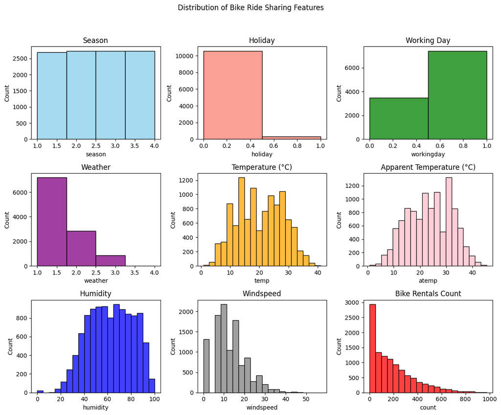

```python
# Create a histogram of all features to show the distribution of each one relative to the data. This is part of the exploritory data analysis

# Create subplots for each feature
fig, axs = plt.subplots(3, 3, figsize=(12, 10))
fig.suptitle('Distribution of Bike Ride Sharing Features')

# Season
sns.histplot(train['season'], bins=4, kde=False, color='skyblue', ax=axs[0, 0])
axs[0, 0].set_title('Season')

# Holiday
sns.histplot(train['holiday'], bins=2, kde=False, color='salmon', ax=axs[0, 1])
axs[0, 1].set_title('Holiday')

# Working Day
sns.histplot(train['workingday'], bins=2, kde=False, color='green', ax=axs[0, 2])
axs[0, 2].set_title('Working Day')

# Weather
sns.histplot(train['weather'], bins=4, kde=False, color='purple', ax=axs[1, 0])
axs[1, 0].set_title('Weather')

# Temperature
sns.histplot(train['temp'], bins=20, kde=False, color='orange', ax=axs[1, 1])
axs[1, 1].set_title('Temperature (°C)')

# Apparent Temperature (Atemp)
sns.histplot(train['atemp'], bins=20, kde=False, color='pink', ax=axs[1, 2])
axs[1, 2].set_title('Apparent Temperature (°C)')

# Humidity
sns.histplot(train['humidity'], bins=20, kde=False, color='blue', ax=axs[2, 0])
axs[2, 0].set_title('Humidity')

# Windspeed
sns.histplot(train['windspeed'], bins=20, kde=False, color='gray', ax=axs[2, 1])
axs[2, 1].set_title('Windspeed')

# Count (Response Variable)
sns.histplot(train['count'], bins=20, kde=False, color='red', ax=axs[2, 2])
axs[2, 2].set_title('Bike Rentals Count')

# Adjust spacing between subplots
plt.tight_layout(rect=[0, 0, 1, 0.95])

# Show the combined histogram
plt.show()
```

### Feature engineering

```python
### add datetime column
train["datetime"] = pd.to_datetime(train.index)
train.head()
```

| datetime | season | holiday | workingday | weather | temp | atemp | humidity | windspeed | count | datetime |
| --- | --- | --- | --- | --- | --- | --- | --- | --- | --- | --- |
| 2011-01-01 00:00:00 | 1 | 0 | 0 | 1 | 9.84 | 14.395 | 81 | 0.0 | 16 | 2011-01-01 00:00:00 |
| 2011-01-01 01:00:00 | 1 | 0 | 0 | 1 | 9.02 | 13.635 | 80 | 0.0 | 40 | 2011-01-01 01:00:00 |
| 2011-01-01 02:00:00 | 1 | 0 | 0 | 1 | 9.02 | 13.635 | 80 | 0.0 | 32 | 2011-01-01 02:00:00 |
| 2011-01-01 03:00:00 | 1 | 0 | 0 | 1 | 9.84 | 14.395 | 75 | 0.0 | 13 | 2011-01-01 03:00:00 |
| 2011-01-01 04:00:00 | 1 | 0 | 0 | 1 | 9.84 | 14.395 | 75 | 0.0 | 1 | 2011-01-01 04:00:00 |

```python
train.dtypes
```

```
season                 int64
holiday                int64
workingday             int64
weather                int64
temp                 float64
atemp                float64
humidity               int64
windspeed            float64
count                  int64
datetime      datetime64[ns]
dtype: object
```

```python
def create_features(df:pd.DataFrame):
    """
    Creates the following new features:

        hour: Extracts the hour from the datetime column.
        rush_hour: Categorizes the hour into ‘morning_rush’, ‘lunch_rush’, ‘evening_rush’, and ‘off_peak’.
        temp_cat: Categorizes the temperature into ‘cold’, ‘mild’, and ‘hot’.
        wind_cat: Categorizes the wind speed into ‘mild_wind’ and ‘very_windy’.
        humidity_cat: Categorizes the humidity into ‘not_humid’ and ‘very_humid’.

    Return  a dataframe with the new columns
    """
    # Extract hour from datetime
    df['hour'] = df['datetime'].dt.hour

    # Define rush hours
    df['rush_hour'] = df['hour'].apply(lambda x: 'morning_rush' if 7 <= x < 9 else
                                        ('lunch_rush' if 11 <= x < 13 else
                                         ('evening_rush' if 17 <= x < 19 else 'off_peak')))

    # Categorize temperature
    df['temp_cat'] = df['temp'].apply(lambda x: 'cold' if x < 10 else
                                      ('mild' if 10 <= x < 25 else 'hot'))

    # Categorize wind speed
    df['wind_cat'] = df['windspeed'].apply(lambda x: 'mild_wind' if x < 10 else 'very_windy')

    # Categorize humidity
    df['humidity_cat'] = df['humidity'].apply(lambda x: 'not_humid' if x < 60 else 'very_humid')

    return df
```

```python
# create the new features
train = create_features(train)
```

```python
train.head()
```

| datetime | season | holiday | workingday | weather | temp | atemp | humidity | windspeed | count | datetime | hour | rush_hour | temp_cat | wind_cat | humidity_cat |
| --- | --- | --- | --- | --- | --- | --- | --- | --- | --- | --- | --- | --- | --- | --- | --- |
| 2011-01-01 00:00:00 | 1 | 0 | 0 | 1 | 9.84 | 14.395 | 81 | 0.0 | 16 | 2011-01-01 00:00:00 | 0 | off_peak | cold | mild_wind | very_humid |
| 2011-01-01 01:00:00 | 1 | 0 | 0 | 1 | 9.02 | 13.635 | 80 | 0.0 | 40 | 2011-01-01 01:00:00 | 1 | off_peak | cold | mild_wind | very_humid |
| 2011-01-01 02:00:00 | 1 | 0 | 0 | 1 | 9.02 | 13.635 | 80 | 0.0 | 32 | 2011-01-01 02:00:00 | 2 | off_peak | cold | mild_wind | very_humid |
| 2011-01-01 03:00:00 | 1 | 0 | 0 | 1 | 9.84 | 14.395 | 75 | 0.0 | 13 | 2011-01-01 03:00:00 | 3 | off_peak | cold | mild_wind | very_humid |
| 2011-01-01 04:00:00 | 1 | 0 | 0 | 1 | 9.84 | 14.395 | 75 | 0.0 | 1 | 2011-01-01 04:00:00 | 4 | off_peak | cold | mild_wind | very_humid |

# install feature-engine

```python
#%pip install feature-engine
```

```python
from feature_engine.datetime import DatetimeFeatures
from feature_engine.creation import CyclicalFeatures
```

### Create cyclical features from `month` and `day_of_month`

We capture the cyclical nature of the `month` and `day_of_month` by transforming those into a par (x,y) or coordinates in polar coordinates They are on a unit circle repeating each year and month respectively. Each `var` will produce 2 new vars:

$$var_x = sin(var * (2 * \frac{pi}{ \text{ max value }} ) ) $$

$$ var_y = cos(var * (2 * \frac{pi}{ \text{max value}})) $$

```python
def get_cyclical_featues(df:pd.DataFrame) ->pd.DataFrame:
    """
    df:
        Dataframe with column "datetime" with type datetime
    """


    # create new columns for year, month, day_of_month
    dtf = DatetimeFeatures(variables = ["datetime"],
        features_to_extract = ["year", "month", "day_of_month"])
    date_features = dtf.fit_transform(df)

    # transform month and day_of_month into polar form (with cyclical nature)
    cf = CyclicalFeatures(
        variables=["datetime_month",
            "datetime_day_of_month"],
        drop_original = True )

    cf.fit(date_features)
    features = cf.transform(date_features)

    return features
```

```python
# create a new feature
train  = get_cyclical_featues(train)
train.head()
```

| datetime | season | holiday | workingday | weather | temp | atemp | humidity | windspeed | count | hour | rush_hour | temp_cat | wind_cat | humidity_cat | datetime_year | datetime_month_sin | datetime_month_cos | datetime_day_of_month_sin | datetime_day_of_month_cos |
| --- | --- | --- | --- | --- | --- | --- | --- | --- | --- | --- | --- | --- | --- | --- | --- | --- | --- | --- | --- |
| 2011-01-01 00:00:00 | 1 | 0 | 0 | 1 | 9.84 | 14.395 | 81 | 0.0 | 16 | 0 | off_peak | cold | mild_wind | very_humid | 2011 | 0.5 | 0.866025 | 0.324699 | 0.945817 |
| 2011-01-01 01:00:00 | 1 | 0 | 0 | 1 | 9.02 | 13.635 | 80 | 0.0 | 40 | 1 | off_peak | cold | mild_wind | very_humid | 2011 | 0.5 | 0.866025 | 0.324699 | 0.945817 |
| 2011-01-01 02:00:00 | 1 | 0 | 0 | 1 | 9.02 | 13.635 | 80 | 0.0 | 32 | 2 | off_peak | cold | mild_wind | very_humid | 2011 | 0.5 | 0.866025 | 0.324699 | 0.945817 |
| 2011-01-01 03:00:00 | 1 | 0 | 0 | 1 | 9.84 | 14.395 | 75 | 0.0 | 13 | 3 | off_peak | cold | mild_wind | very_humid | 2011 | 0.5 | 0.866025 | 0.324699 | 0.945817 |
| 2011-01-01 04:00:00 | 1 | 0 | 0 | 1 | 9.84 | 14.395 | 75 | 0.0 | 1 | 4 | off_peak | cold | mild_wind | very_humid | 2011 | 0.5 | 0.866025 | 0.324699 | 0.945817 |

```python
# check for duplicate cols
train.columns.duplicated().sum()
```

```
0
```

```python
# create features for the test set
# first add the datetime column
test["datetime"] = pd.to_datetime(test.index)

test = create_features(test)
test = get_cyclical_featues(test)
test.head()
```

| datetime | season | holiday | workingday | weather | temp | atemp | humidity | windspeed | hour | rush_hour | temp_cat | wind_cat | humidity_cat | datetime_year | datetime_month_sin | datetime_month_cos | datetime_day_of_month_sin | datetime_day_of_month_cos |
| --- | --- | --- | --- | --- | --- | --- | --- | --- | --- | --- | --- | --- | --- | --- | --- | --- | --- | --- |
| 2011-01-20 00:00:00 | 1 | 0 | 1 | 1 | 10.66 | 11.365 | 56 | 26.0027 | 0 | off_peak | mild | very_windy | not_humid | 2011 | 0.5 | 0.866025 | -0.790776 | -0.612106 |
| 2011-01-20 01:00:00 | 1 | 0 | 1 | 1 | 10.66 | 13.635 | 56 | 0.0000 | 1 | off_peak | mild | mild_wind | not_humid | 2011 | 0.5 | 0.866025 | -0.790776 | -0.612106 |
| 2011-01-20 02:00:00 | 1 | 0 | 1 | 1 | 10.66 | 13.635 | 56 | 0.0000 | 2 | off_peak | mild | mild_wind | not_humid | 2011 | 0.5 | 0.866025 | -0.790776 | -0.612106 |
| 2011-01-20 03:00:00 | 1 | 0 | 1 | 1 | 10.66 | 12.880 | 56 | 11.0014 | 3 | off_peak | mild | very_windy | not_humid | 2011 | 0.5 | 0.866025 | -0.790776 | -0.612106 |
| 2011-01-20 04:00:00 | 1 | 0 | 1 | 1 | 10.66 | 12.880 | 56 | 11.0014 | 4 | off_peak | mild | very_windy | not_humid | 2011 | 0.5 | 0.866025 | -0.790776 | -0.612106 |

```python
# number of duplicated columns
test.columns.duplicated().sum()
```

```
0
```

## Make category types for these so models know they are not just numbers

- AutoGluon originally sees these as ints, but in reality they are int representations of a category.
- Setting the dtype to category will classify these as categories in AutoGluon.

```python
train["season"] = train["season"].astype("category")
train["weather"] = train["weather"].astype("category")
test["season"] = test["season"].astype("category")
test["weather"] = test["weather"].astype("category")
```

```python
# visualize new features in table
train[ ["rush_hour", "temp_cat", "wind_cat",
"humidity_cat"]]
```

| datetime | rush_hour | temp_cat | wind_cat | humidity_cat |
| --- | --- | --- | --- | --- |
| 2011-01-01 00:00:00 | off_peak | cold | mild_wind | very_humid |
| 2011-01-01 01:00:00 | off_peak | cold | mild_wind | very_humid |
| 2011-01-01 02:00:00 | off_peak | cold | mild_wind | very_humid |
| 2011-01-01 03:00:00 | off_peak | cold | mild_wind | very_humid |
| 2011-01-01 04:00:00 | off_peak | cold | mild_wind | very_humid |
| ... | ... | ... | ... | ... |
| 2012-12-19 19:00:00 | off_peak | mild | very_windy | not_humid |
| 2012-12-19 20:00:00 | off_peak | mild | very_windy | not_humid |
| 2012-12-19 21:00:00 | off_peak | mild | very_windy | very_humid |
| 2012-12-19 22:00:00 | off_peak | mild | mild_wind | very_humid |
| 2012-12-19 23:00:00 | off_peak | mild | mild_wind | very_humid |

10886 rows × 4 columns

```python
# cast features to category type

train["rush_hour"]   = train["rush_hour"].astype("category")
train["temp_cat"]   = train["temp_cat"].astype("category")
train["wind_cat"]   = train["wind_cat"].astype("category")
train["humidity_cat"]   = train["humidity_cat"].astype("category")
```

```python
train.dtypes
```

```
season                       category
holiday                         int64
workingday                      int64
weather                      category
temp                          float64
atemp                         float64
humidity                        int64
windspeed                     float64
count                           int64
hour                            int32
rush_hour                    category
temp_cat                     category
wind_cat                     category
humidity_cat                 category
datetime_year                   int32
datetime_month_sin            float64
datetime_month_cos            float64
datetime_day_of_month_sin     float64
datetime_day_of_month_cos     float64
dtype: object
```

```python
train.head()
```

| datetime | season | holiday | workingday | weather | temp | atemp | humidity | windspeed | count | hour | rush_hour | temp_cat | wind_cat | humidity_cat | datetime_year | datetime_month_sin | datetime_month_cos | datetime_day_of_month_sin | datetime_day_of_month_cos |
| --- | --- | --- | --- | --- | --- | --- | --- | --- | --- | --- | --- | --- | --- | --- | --- | --- | --- | --- | --- |
| 2011-01-01 00:00:00 | 1 | 0 | 0 | 1 | 9.84 | 14.395 | 81 | 0.0 | 16 | 0 | off_peak | cold | mild_wind | very_humid | 2011 | 0.5 | 0.866025 | 0.324699 | 0.945817 |
| 2011-01-01 01:00:00 | 1 | 0 | 0 | 1 | 9.02 | 13.635 | 80 | 0.0 | 40 | 1 | off_peak | cold | mild_wind | very_humid | 2011 | 0.5 | 0.866025 | 0.324699 | 0.945817 |
| 2011-01-01 02:00:00 | 1 | 0 | 0 | 1 | 9.02 | 13.635 | 80 | 0.0 | 32 | 2 | off_peak | cold | mild_wind | very_humid | 2011 | 0.5 | 0.866025 | 0.324699 | 0.945817 |
| 2011-01-01 03:00:00 | 1 | 0 | 0 | 1 | 9.84 | 14.395 | 75 | 0.0 | 13 | 3 | off_peak | cold | mild_wind | very_humid | 2011 | 0.5 | 0.866025 | 0.324699 | 0.945817 |
| 2011-01-01 04:00:00 | 1 | 0 | 0 | 1 | 9.84 | 14.395 | 75 | 0.0 | 1 | 4 | off_peak | cold | mild_wind | very_humid | 2011 | 0.5 | 0.866025 | 0.324699 | 0.945817 |

```python
test.head()
```

| datetime | season | holiday | workingday | weather | temp | atemp | humidity | windspeed | hour | rush_hour | temp_cat | wind_cat | humidity_cat | datetime_year | datetime_month_sin | datetime_month_cos | datetime_day_of_month_sin | datetime_day_of_month_cos |
| --- | --- | --- | --- | --- | --- | --- | --- | --- | --- | --- | --- | --- | --- | --- | --- | --- | --- | --- |
| 2011-01-20 00:00:00 | 1 | 0 | 1 | 1 | 10.66 | 11.365 | 56 | 26.0027 | 0 | off_peak | mild | very_windy | not_humid | 2011 | 0.5 | 0.866025 | -0.790776 | -0.612106 |
| 2011-01-20 01:00:00 | 1 | 0 | 1 | 1 | 10.66 | 13.635 | 56 | 0.0000 | 1 | off_peak | mild | mild_wind | not_humid | 2011 | 0.5 | 0.866025 | -0.790776 | -0.612106 |
| 2011-01-20 02:00:00 | 1 | 0 | 1 | 1 | 10.66 | 13.635 | 56 | 0.0000 | 2 | off_peak | mild | mild_wind | not_humid | 2011 | 0.5 | 0.866025 | -0.790776 | -0.612106 |
| 2011-01-20 03:00:00 | 1 | 0 | 1 | 1 | 10.66 | 12.880 | 56 | 11.0014 | 3 | off_peak | mild | very_windy | not_humid | 2011 | 0.5 | 0.866025 | -0.790776 | -0.612106 |
| 2011-01-20 04:00:00 | 1 | 0 | 1 | 1 | 10.66 | 12.880 | 56 | 11.0014 | 4 | off_peak | mild | very_windy | not_humid | 2011 | 0.5 | 0.866025 | -0.790776 | -0.612106 |

```python
train.describe()
```

|  | holiday | workingday | temp | atemp | humidity | windspeed | count | hour | datetime_year | datetime_month_sin | datetime_month_cos | datetime_day_of_month_sin | datetime_day_of_month_cos |
| --- | --- | --- | --- | --- | --- | --- | --- | --- | --- | --- | --- | --- | --- |
| count | 10886.000000 | 10886.000000 | 10886.00000 | 10886.000000 | 10886.000000 | 10886.000000 | 10886.000000 | 10886.000000 | 10886.000000 | 1.088600e+04 | 1.088600e+04 | 1.088600e+04 | 10886.000000 |
| mean | 0.028569 | 0.680875 | 20.23086 | 23.655084 | 61.886460 | 12.799395 | 191.574132 | 11.541613 | 2011.501929 | -3.009216e-03 | -2.720442e-03 | 4.667492e-04 | -0.000215 |
| std | 0.166599 | 0.466159 | 7.79159 | 8.474601 | 19.245033 | 8.164537 | 181.144454 | 6.915838 | 0.500019 | 7.069055e-01 | 7.073613e-01 | 7.075049e-01 | 0.706773 |
| min | 0.000000 | 0.000000 | 0.82000 | 0.760000 | 0.000000 | 0.000000 | 1.000000 | 0.000000 | 2011.000000 | -1.000000e+00 | -1.000000e+00 | -9.965845e-01 | -0.986361 |
| 25% | 0.000000 | 0.000000 | 13.94000 | 16.665000 | 47.000000 | 7.001500 | 42.000000 | 6.000000 | 2011.000000 | -8.660254e-01 | -8.660254e-01 | -7.357239e-01 | -0.677282 |
| 50% | 0.000000 | 1.000000 | 20.50000 | 24.240000 | 62.000000 | 12.998000 | 145.000000 | 12.000000 | 2012.000000 | -2.449294e-16 | -1.836970e-16 | -2.449294e-16 | -0.082579 |
| 75% | 0.000000 | 1.000000 | 26.24000 | 31.060000 | 77.000000 | 16.997900 | 284.000000 | 18.000000 | 2012.000000 | 5.000000e-01 | 5.000000e-01 | 7.357239e-01 | 0.789141 |
| max | 1.000000 | 1.000000 | 41.00000 | 45.455000 | 100.000000 | 56.996900 | 977.000000 | 23.000000 | 2012.000000 | 1.000000e+00 | 1.000000e+00 | 9.965845e-01 | 1.000000 |

```python
len(train.dtypes)
```

```
19
```

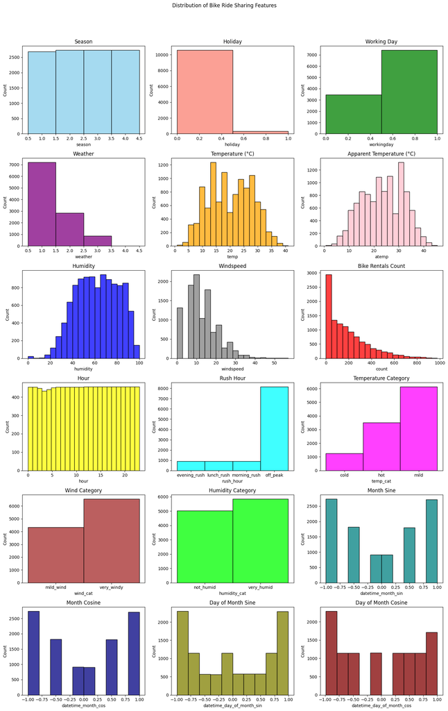

```python
# View histogram of all features again now with the hour feature
# Create a histogram of all features to show the distribution of each one relative to the data. This is part of the exploratory data analysis

# Create subplots for each feature
fig, axs = plt.subplots(6, 3, figsize=(15, 24))
fig.suptitle('Distribution of Bike Ride Sharing Features')

# Season
sns.histplot(train['season'], bins=4, kde=False, color='skyblue', ax=axs[0, 0])
axs[0, 0].set_title('Season')

# Holiday
sns.histplot(train['holiday'], bins=2, kde=False, color='salmon', ax=axs[0, 1])
axs[0, 1].set_title('Holiday')

# Working Day
sns.histplot(train['workingday'], bins=2, kde=False, color='green', ax=axs[0, 2])
axs[0, 2].set_title('Working Day')

# Weather
sns.histplot(train['weather'], bins=4, kde=False, color='purple', ax=axs[1, 0])
axs[1, 0].set_title('Weather')

# Temperature
sns.histplot(train['temp'], bins=20, kde=False, color='orange', ax=axs[1, 1])
axs[1, 1].set_title('Temperature (°C)')

# Apparent Temperature (Atemp)
sns.histplot(train['atemp'], bins=20, kde=False, color='pink', ax=axs[1, 2])
axs[1, 2].set_title('Apparent Temperature (°C)')

# Humidity
sns.histplot(train['humidity'], bins=20, kde=False, color='blue', ax=axs[2, 0])
axs[2, 0].set_title('Humidity')

# Windspeed
sns.histplot(train['windspeed'], bins=20, kde=False, color='gray', ax=axs[2, 1])
axs[2, 1].set_title('Windspeed')

# Count (Response Variable)
sns.histplot(train['count'], bins=20, kde=False, color='red', ax=axs[2, 2])
axs[2, 2].set_title('Bike Rentals Count')

# Hour
sns.histplot(train['hour'], bins=24, kde=False, color='yellow', ax=axs[3, 0])
axs[3, 0].set_title('Hour')

# Rush Hour
sns.histplot(train['rush_hour'], kde=False, color='cyan', ax=axs[3, 1])
axs[3, 1].set_title('Rush Hour')

# Temperature Category
sns.histplot(train['temp_cat'], kde=False, color='magenta', ax=axs[3, 2])
axs[3, 2].set_title('Temperature Category')

# Wind Category
sns.histplot(train['wind_cat'], kde=False, color='brown', ax=axs[4, 0])
axs[4, 0].set_title('Wind Category')

# Humidity Category
sns.histplot(train['humidity_cat'], kde=False, color='lime', ax=axs[4, 1])
axs[4, 1].set_title('Humidity Category')

#datetime_year is not plotted, their values newer repeats

# Month Sine
sns.histplot(train['datetime_month_sin'], bins=10, kde=False, color='teal', ax=axs[4, 2])
axs[4, 2].set_title('Month Sine')

# Month Cosine
sns.histplot(train['datetime_month_cos'], bins=10, kde=False, color='navy', ax=axs[5, 0])
axs[5, 0].set_title('Month Cosine')

# Day of Month Sine
sns.histplot(train['datetime_day_of_month_sin'], bins=10, kde=False, color='olive', ax=axs[5, 1])
axs[5, 1].set_title('Day of Month Sine')

# Day of Month Cosine
sns.histplot(train['datetime_day_of_month_cos'], bins=10, kde=False, color='maroon', ax=axs[5, 2])
axs[5, 2].set_title('Day of Month Cosine')

# Adjust spacing between subplots
plt.tight_layout(rect=[0, 0, 1, 0.95])

# Show the combined histogram
plt.show()
```

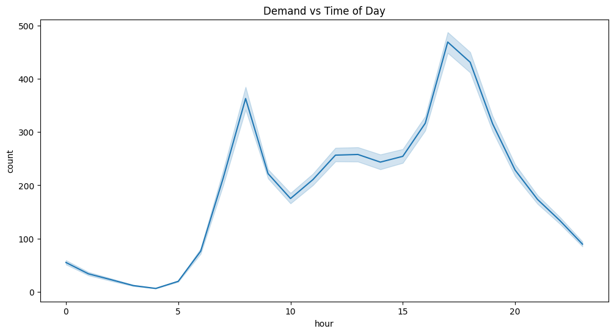

```python
# Plotting demand vs time_of_day
plt.figure(figsize=(12, 6))
sns.lineplot(data=train, x='hour', y='count')
plt.title('Demand vs Time of Day')
plt.show()
```

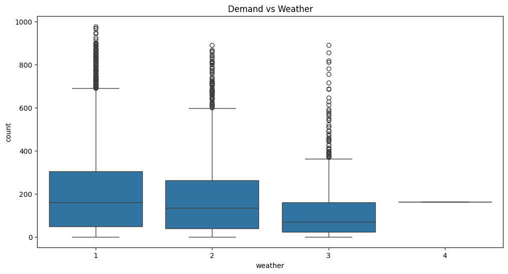

```python
# Plotting demand vs weather
plt.figure(figsize=(12, 6))
sns.boxplot(data=train, x='weather', y='count')
plt.title('Demand vs Weather')
plt.show()
```

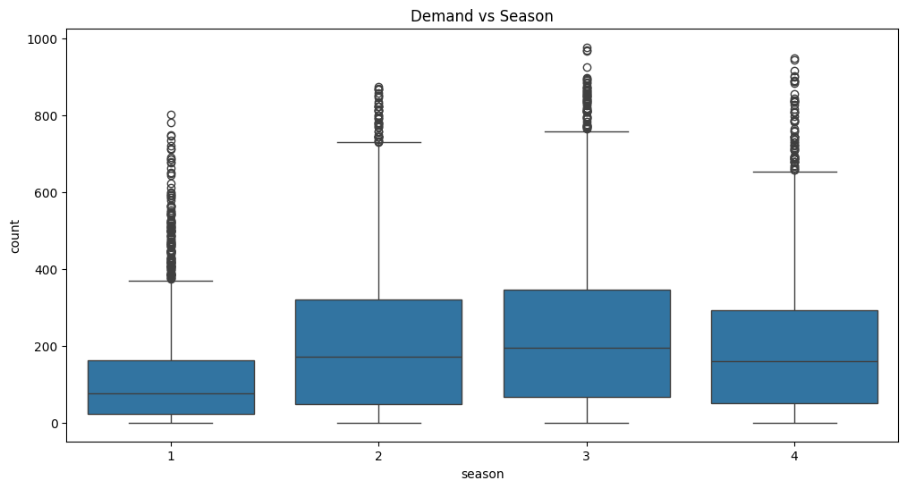

```python
# Plotting demand vs season
plt.figure(figsize=(12, 6))
sns.boxplot(data=train, x='season', y='count')
plt.title('Demand vs Season')
plt.show()
```